# ADGRs in lymphatic endothelial cells in scRNA-seq datasets

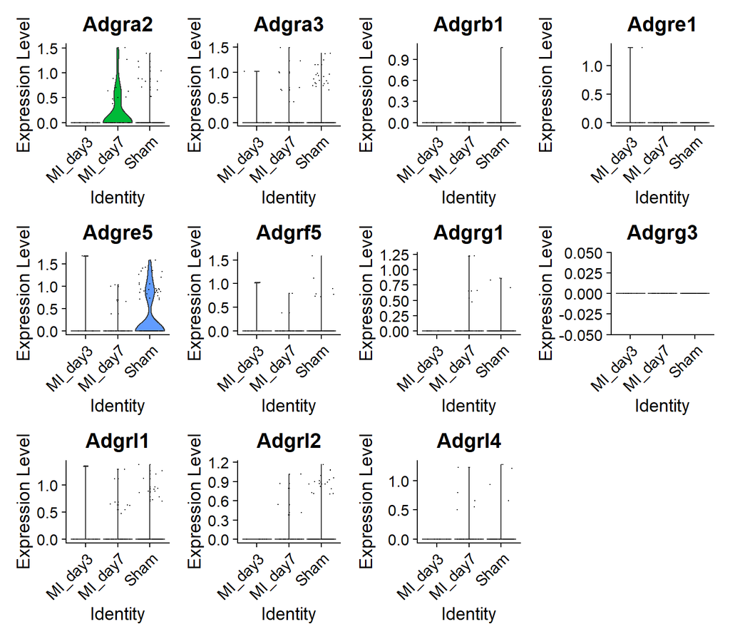

```r
VlnPlot(TIP_MI_EC, features =c("Adgra2", "Adgra3","Adgrb1",
                                 "Adgre1", "Adgre5", "Adgrf5",
                                 "Adgrg1", "Adgrg3", "Adgrl1",
                                 "Adgrl2", "Adgrl4"),
        idents = 15,
        group.by = "sample",
        pt.size=0.1)
```

## Dataset2: postTAC mouse heart(Ren et al. 2020)

### Identification of LEC clusters

This dataset contains cell type information, which includes 9 clusters of EC. Here we will use the same LEC markers as before to identify the possible LEC clusters among them.

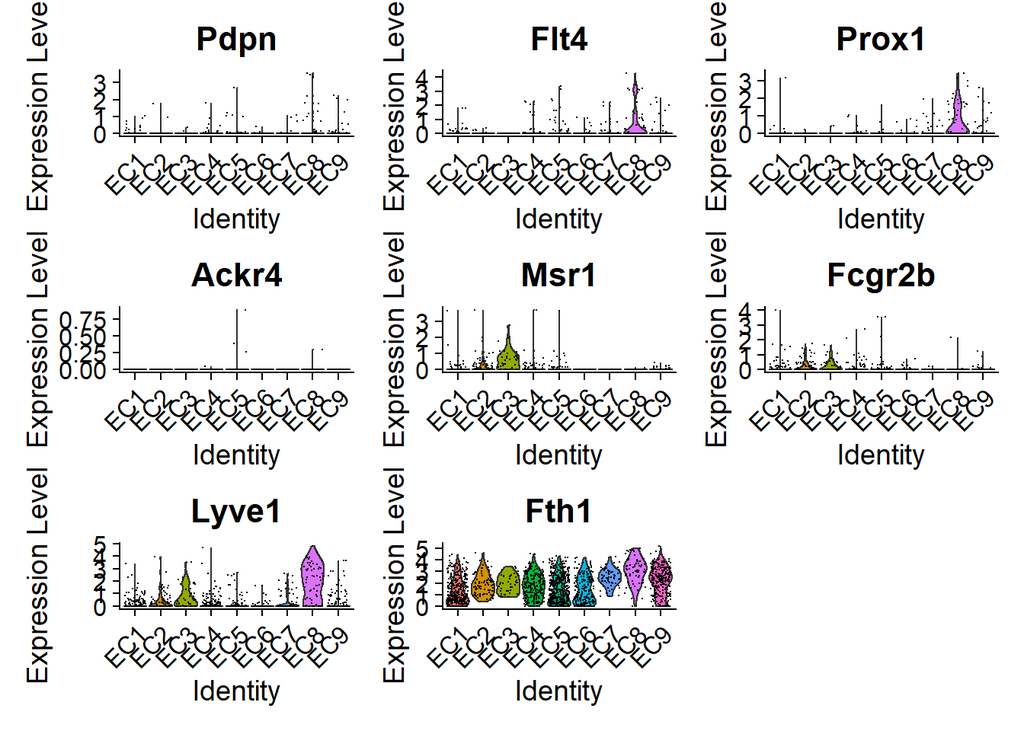

```r
load("../data/GSE120064_TAC CM_NMCC_mtx_cell_info/clean/TAC_EC_umap.rdata")

VlnPlot(EC, features = c("Pdpn","Flt4","Prox1","Ackr4","Msr1","Fcgr2b",
                                  "Lyve1", "Fth1"),
        pt.size = 0.1)
```

We will include cluster 2, 3 and 8 as LEC and examine the ADGRs in them.

### ADGRs expression in LEC

Again, we’ll plot ADGRs in all EC clusters to keep things in perspective.

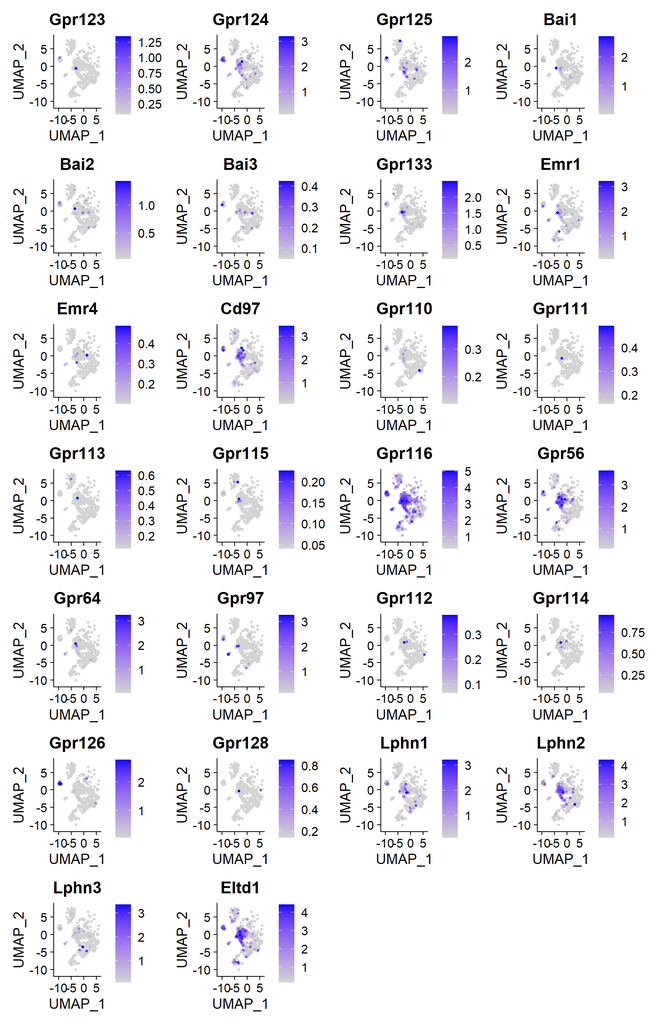

```r
ADGR_list_oldname <- c("Gpr123", "Gpr124", "Gpr125",
                       "Bai1", "Bai2", "Bai3",
                       "Cselr1", "Cselr2", "Cselr3",
                       "Gpr133", "Gpr144",
                       "Emr1", "Emr2", "Emr3", "Emr4", "Cd97",
                       'Gpr110', "Gpr111", "Gpr113", "Gpr115", "Gpr116",
                       "Gpr56", "Gpr64", "Gpr97", "Gpr112", "Gpr114", 'Gpr126', "Gpr128",
                       'Lphn1', 'Lphn2', 'Lphn3', "Eltd1", "Vlgr1")

FeaturePlot(EC,
            reduction = "umap",
            features= ADGR_list_oldname,
            sort.cell = TRUE,
            min.cutoff = 'q10')
```

The undetectable ADGRs are left out from the plot above. Sub-clusters labels are not shown for better visualization of the expression levels. For the ones with relatively higher expression (Gpr124, GPr125, Emr1, Cd97, Gpr116, Gpr56, Lphn1, Lphn2 and Eltd1), we’ll include them for further examination. For the other ones with sporadic expression, we will use violin plot to check the expression levels in different subclusters more directly.

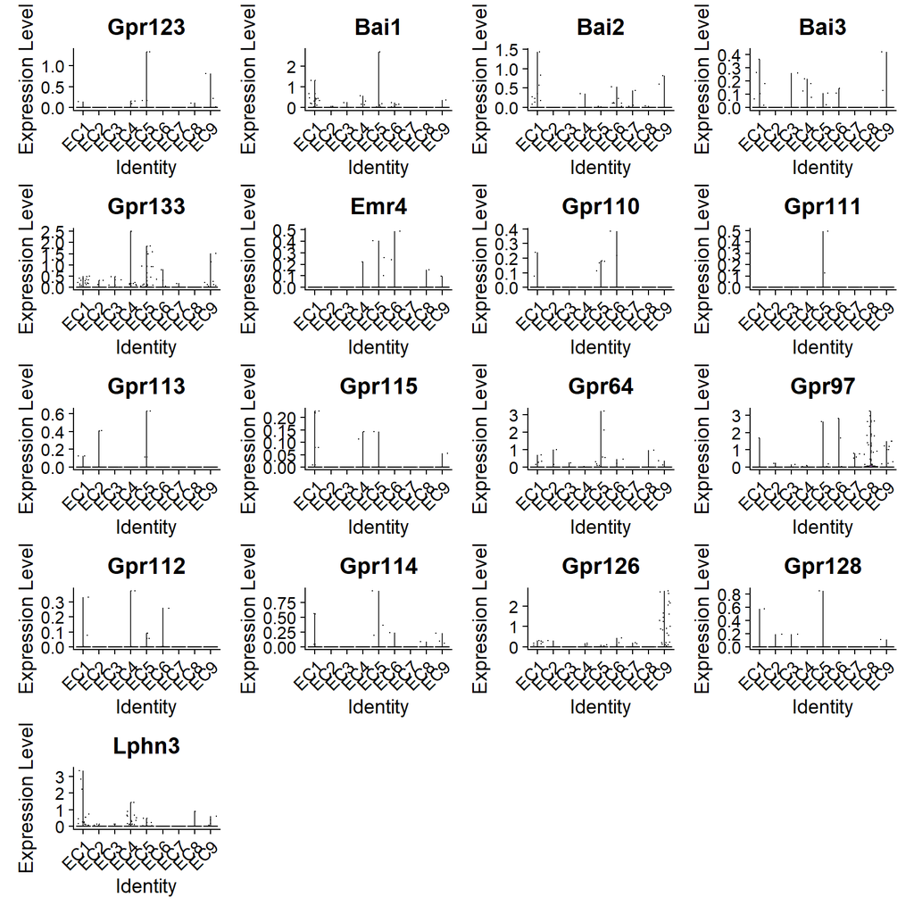

```r
VlnPlot(EC, features = c("Gpr123", "Bai1", "Bai2",
                         "Bai3", "Gpr133", "Emr4", "Gpr110",
                         "Gpr111", "Gpr113", "Gpr115", "Gpr64",
                         'Gpr97', 'Gpr112', 'Gpr114', "Gpr126", "Gpr128", 'Lphn3'))
```

After narrowing down the list, we can now visualize expression levels of these ADGRs in different conditions.

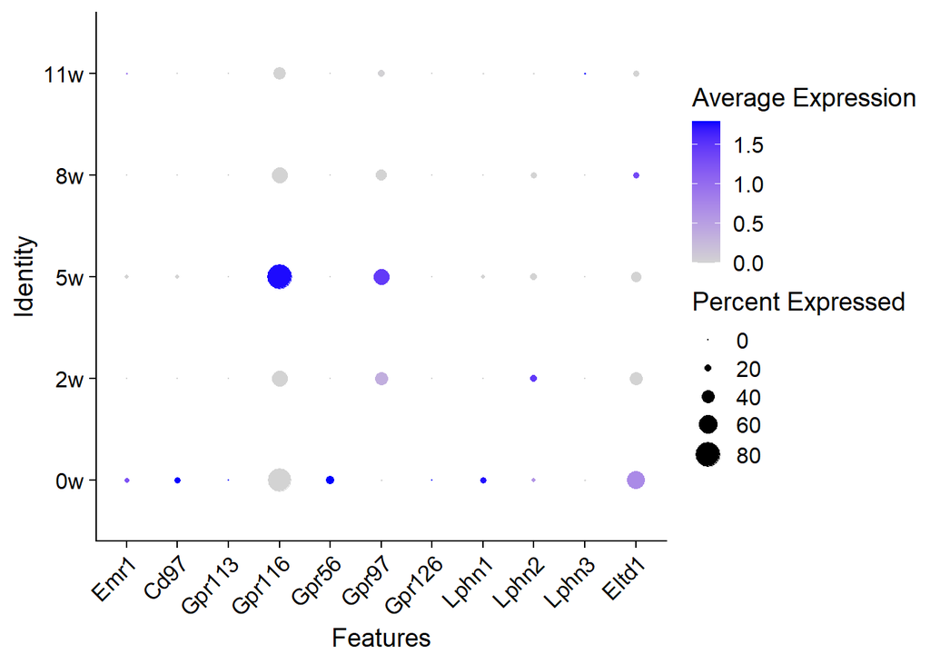

```r
load("../data/GSE120064_TAC CM_NMCC_mtx_cell_info/clean/TAC_LEC_metadata.rdata")

DotPlot(TAC_LEC,
        features = c("Emr1",  "Cd97",
                     "Gpr113",  "Gpr116",
                     "Gpr56", "Gpr97",  'Gpr126',
                     'Lphn1', 'Lphn2', 'Lphn3', "Eltd1"),
        col.min = 0, col.max = 3,
        dot.min = 0, dot.scale = 6)+
  theme(axis.text.x = element_text(angle = 45, vjust = 1, hjust=1))
```

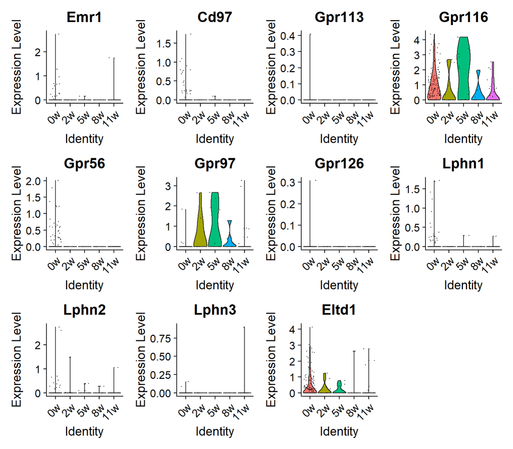

```r
VlnPlot(TAC_LEC,
        features = c("Emr1",  "Cd97",
                     "Gpr113",  "Gpr116",
                     "Gpr56", "Gpr97",  'Gpr126',
                     'Lphn1', 'Lphn2', 'Lphn3', "Eltd1"),
        pt.size=0.1)
```

Lastly, we’ll look at individual LEC cluster to explore possible pattern.

**EC2**

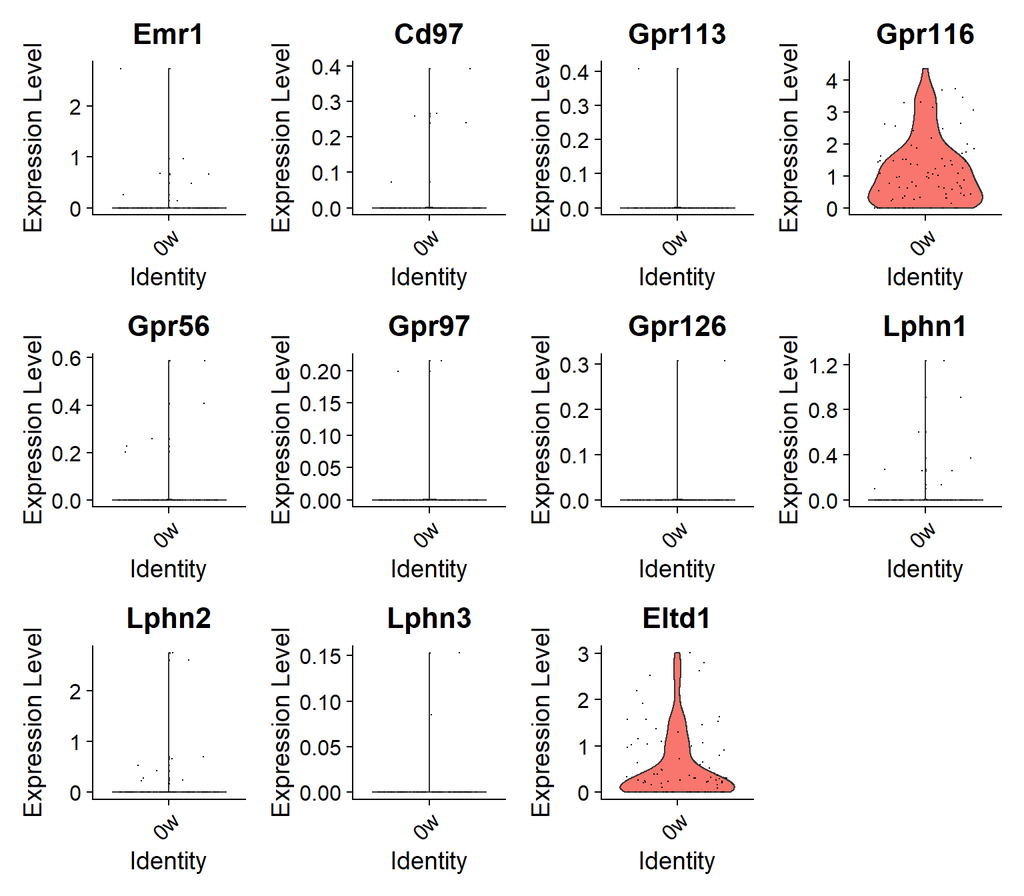

```r
metadata_lec <- TAC_LEC@meta.data

Idents(TAC_LEC) <- metadata_lec$SubCluster

VlnPlot(TAC_LEC,
        features = c("Emr1",  "Cd97",
                     "Gpr113",  "Gpr116",
                     "Gpr56", "Gpr97",  'Gpr126',
                     'Lphn1', 'Lphn2', 'Lphn3', "Eltd1"),
        idents = "EC2",
        group.by = "condition")
```

**EC3**

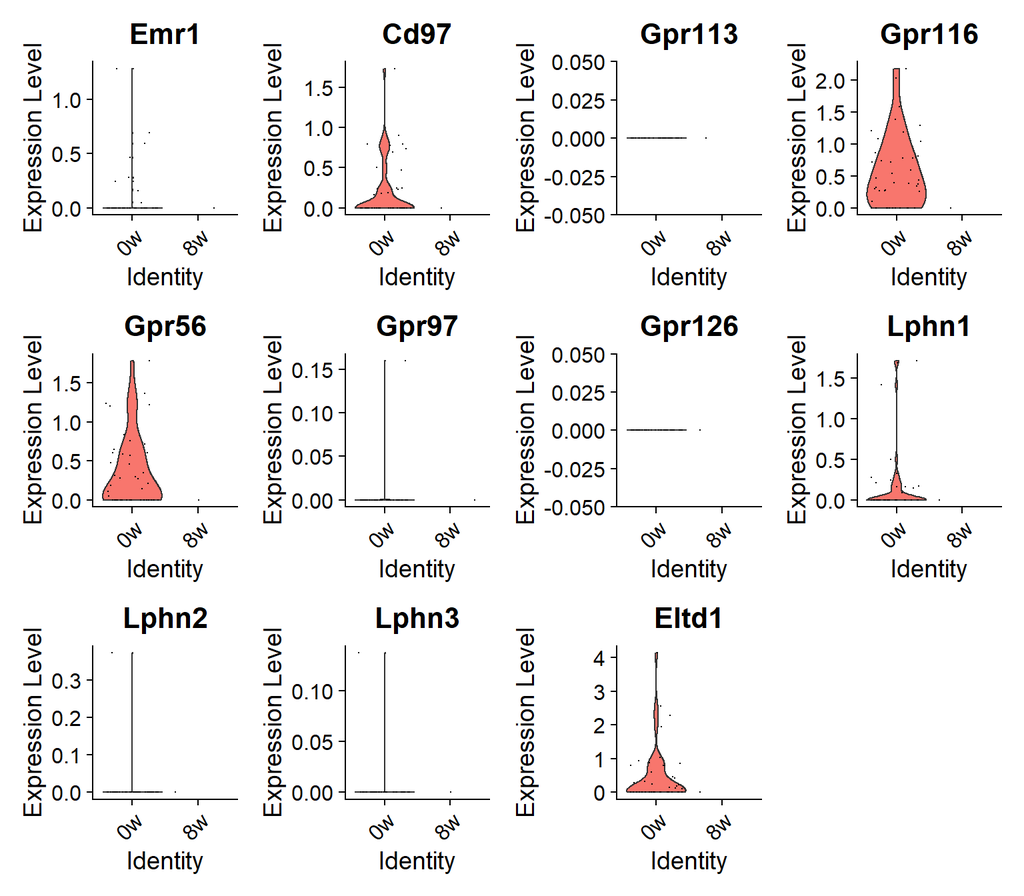

```r
VlnPlot(TAC_LEC,
        features = c("Emr1",  "Cd97",
                     "Gpr113",  "Gpr116",
                     "Gpr56", "Gpr97",  'Gpr126',
                     'Lphn1', 'Lphn2', 'Lphn3', "Eltd1"),
        idents = "EC3",
        group.by = "condition")
```

Interestingly, both EC2 and EC3 show detectable expression only at baseline (0w) for the ADGRs examined, while EC8 cells express several ADGRs in all 5 different conditions.

**EC8**

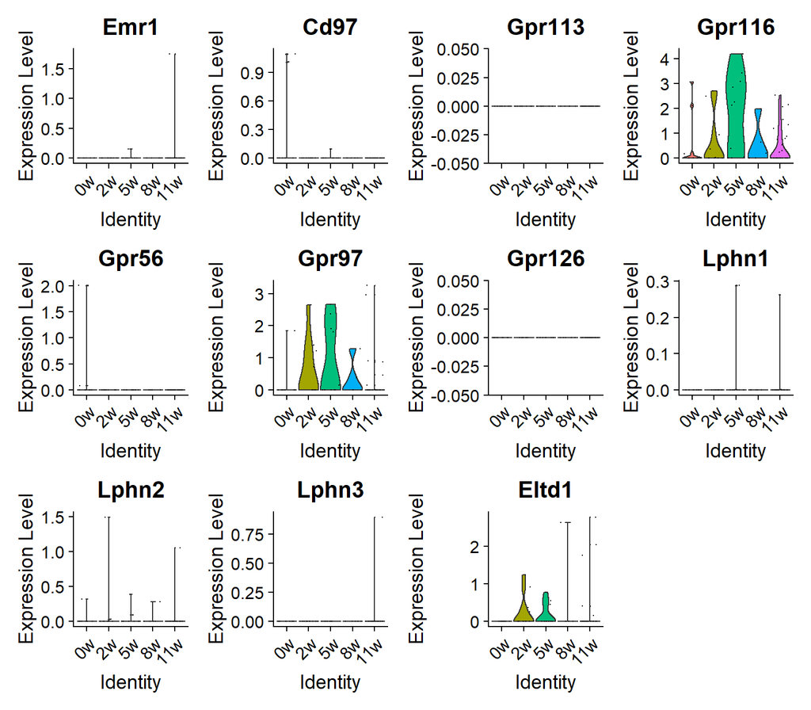

```r
load("../data/GSE120064_TAC CM_NMCC_mtx_cell_info/clean/TAC_LEC_cluster8_condition.rdata")

VlnPlot(TAC_LEC8,
        features = c("Emr1",  "Cd97",
                     "Gpr113",  "Gpr116",
                     "Gpr56", "Gpr97",  'Gpr126',
                     'Lphn1', 'Lphn2', 'Lphn3', "Eltd1"))
```

## References

Farbehi, Nona, Ralph Patrick, Aude Dorison, Munira Xaymardan, Vaibhao Janbandhu, Katharina Wystub-Lis, Joshua WK Ho, Robert E Nordon, and Richard P Harvey. 2019. “Single-Cell Expression Profiling Reveals Dynamic Flux of Cardiac Stromal, Vascular and Immune Cells in Health and Injury.” *eLife* 8 (March). https://doi.org/10.7554/elife.43882.

Ren, Zongna, Peng Yu, Dandan Li, Zheng Li, Yingnan Liao, Yin Wang, Bingying Zhou, and Li Wang. 2020. “Single-Cell Reconstruction of Progression Trajectory Reveals Intervention Principles in Pathological Cardiac Hypertrophy.” *Circulation* 141 (21): 1704–19. https://doi.org/10.1161/circulationaha.119.043053.